# Implementando ICs

Jayne Morais

# L3P2: ICs via bootstrap

## Jayne Morais - Mestrado UFCG 2019.1

## Os dados

```r
set.seed(12345)

lastfm = read_csv(here::here("data/experimento-lastfm.csv"),
                  col_types = cols(.default = col_double(),
                                   user = col_character()))
lastfm = lastfm %>%
  sample_n(300) %>%
  select(news, old, mediana_pop)

glimpse(lastfm)
```

```
## Observations: 300
## Variables: 3
## $ news        <dbl> 25, 13, 21, 18, 10, 11, 29, 51, 23, 11, 22, 35, 77, …
## $ old         <dbl> 103, 61, 62, 180, 55, 68, 120, 45, 61, 116, 68, 83, …
## $ mediana_pop <dbl> 5.966097, 5.745970, 5.195969, 5.595928, 5.900597, 6.…
```

## Proporção de artistas novos e popularidade

Utilizaremos ICs para estimar duas métricas sobre os usuários do LastFM em geral durante um período de 6 meses. Em ambos os casos faremos isso a partir de uma amostra de 300 usuários. As duas métricas são:

## 1. Qual a proporção de novos artistas em geral escutada por usuários?

#### a. Implementando bootstraps manualmente

Primeiramente gera-se uma nova coluna, a qual contém a proporção de novos artistas:

```r
minha_amostra = lastfm %>%
    mutate(proporcao_novos_artitas = (news / (news + old)))

minha_amostra
```

| news | old | mediana_pop | proporcao_novos_artitas |
| --- | --- | --- | --- |
| 25 | 103 | 5.966097 | 0.19531250 |
| 13 | 61 | 5.745970 | 0.17567568 |
| 21 | 62 | 5.195969 | 0.25301205 |
| 18 | 180 | 5.595928 | 0.09090909 |
| 10 | 55 | 5.900597 | 0.15384615 |
| 11 | 68 | 6.118659 | 0.13924051 |
| 29 | 120 | 5.291664 | 0.19463087 |
| 51 | 45 | 5.168289 | 0.53125000 |
| 23 | 61 | 5.085683 | 0.27380952 |
| 11 | 116 | 5.679136 | 0.08661417 |

[output cut: 290 more lines]

```r
funcao_theta = function(df) {
  df %>%
    pull(proporcao_novos_artitas) %>% #Tranforma uma coluna e um vetor
    mean()
}

# theta = funcao_theta(minha_amostra)

theta_c = funcao_theta(minha_amostra)
```

Gera-se manualmente 4000 reamostragens a partir da amostra de 300, em seguida pode-se observar a distribuição dos dados gerados pela reamostragem $(\hat{\theta}*)$ e a diferença entre a distribuição da amostra e da reamostra $(\hat{\theta}* - \hat{\theta})$.

```r
meu_primeiro_bootstrap <- function(x){
  proporcao_novos_artitas = x %>% pull(proporcao_novos_artitas)
  boot_x <- sample(proporcao_novos_artitas,           # amostre dos dados
  size = NROW(proporcao_novos_artitas), # tamanho igual ao recebido
  replace = TRUE) # aqui é o bootstrap

  return(mean(boot_x))
}
set.seed(1212)

repeticoes = 4000

# A REAMOSTRAGEM
reamostragens = tibble(i = 1:repeticoes) %>%
  mutate(theta_c_s = map_dbl(i, ~ meu_primeiro_bootstrap(minha_amostra)))

reamostragens
```

| i | theta_c_s |
| --- | --- |
| 1 | 0.2357924 |
| 2 | 0.2453573 |
| 3 | 0.2380605 |
| 4 | 0.2409805 |
| 5 | 0.2370101 |
| 6 | 0.2467609 |
| 7 | 0.2450844 |
| 8 | 0.2341312 |
| 9 | 0.2608432 |
| 10 | 0.2411255 |

[output cut: 3990 more lines]

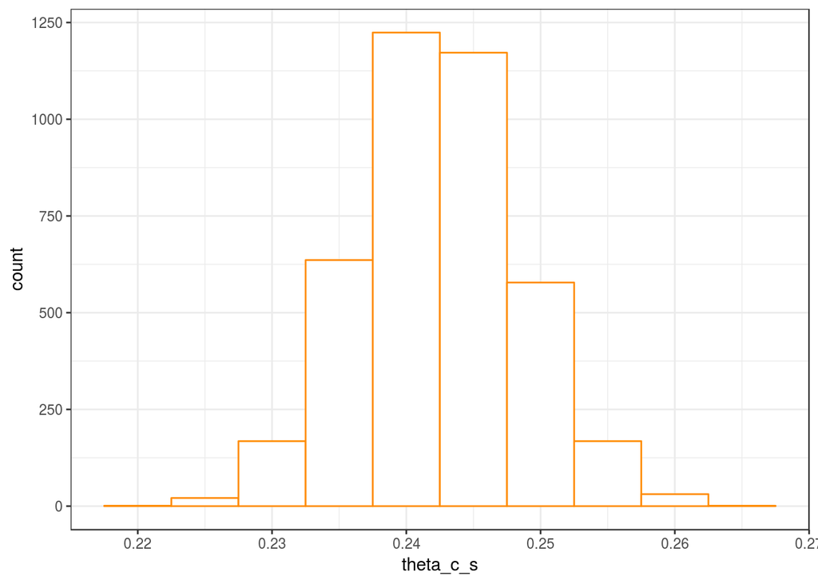

```r
ci_amostragens = reamostragens %>%
  mutate(erro = theta_c_s - theta_c) %>%
  mutate(conf.low = theta_c + quantile(erro, .025),
         conf.high = theta_c + quantile(erro, .975),
         statistic = theta_c) %>%
  select(conf.low, statistic, conf.high)


reamostragens %>%
  ggplot(aes(x = theta_c_s)) +
  geom_histogram(binwidth = .005,
                 colour = "darkorange",
                 fill = "white")
```

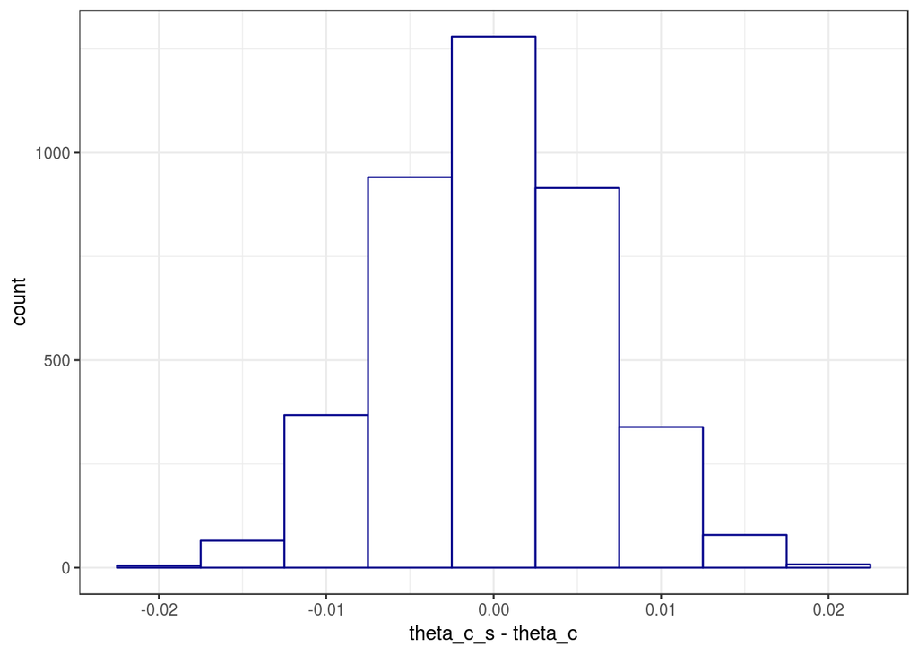

```r
reamostragens %>%
  ggplot(aes(x = theta_c_s - theta_c)) +
  geom_histogram(binwidth = .005,
                 colour = "darkblue",
                 fill = "white")
```

### Calculando o IC

Agora usamos a distribuição de $\delta* = \hat{\theta}* - \hat{\theta}$ no lugar da de $\delta$.

```r
intervalo = reamostragens %>%
  mutate(erro = theta_c_s - theta_c) %>%
  summarise(erro_i = quantile(erro, .025),
            erro_s = quantile(erro, .975))

#intervalo
```

Agora fazemos o mesmo que antes para estimar onde $\theta$ está usando $\hat{\theta}$.

```r
intervalo = intervalo %>%
  mutate(valor_i = theta_c + erro_i,
         valor_s = theta_c + erro_s)

intervalo
```

| erro_i | erro_s | valor_i | valor_s |
| --- | --- | --- | --- |
| -0.01152844 | 0.01209833 | 0.2308375 | 0.2544643 |

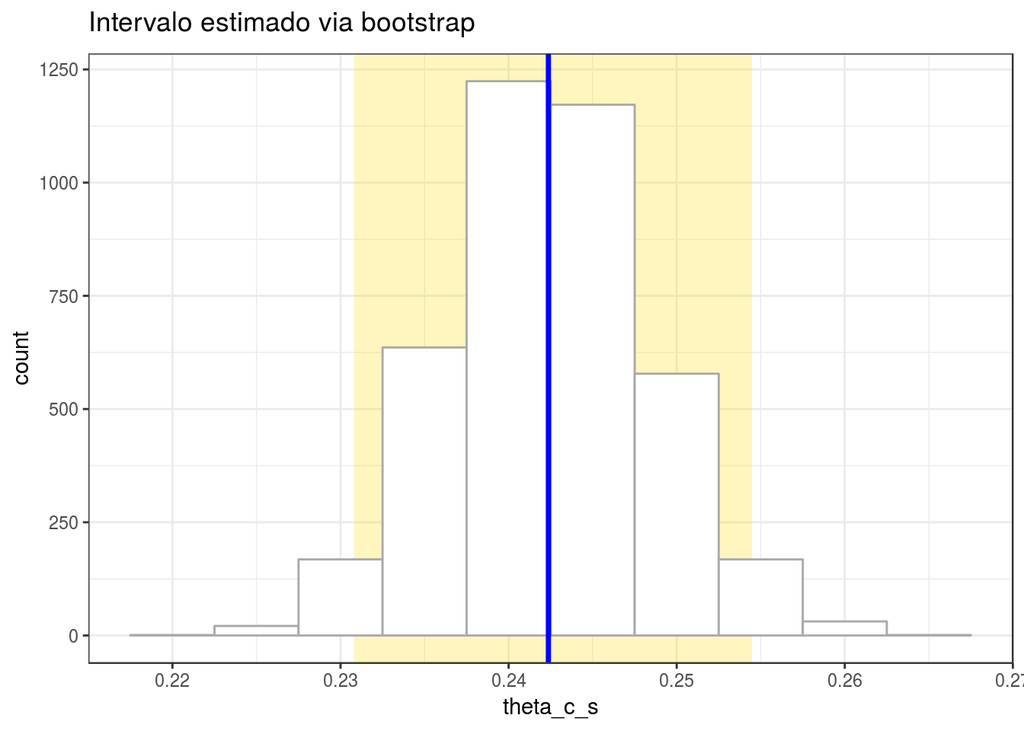

```r
ggplot() +
  geom_rect(
    data = intervalo,
    aes(xmin = valor_i, xmax = valor_s),
    ymin = -Inf,
    ymax = Inf,
    fill = "gold",
    alpha = .25
  ) +
  geom_histogram(
    data = reamostragens,
    aes(theta_c_s),
    binwidth = .005,
    fill = "white",
    colour = "darkgrey"
  ) +
  geom_vline(xintercept = theta_c,
             color = "blue",
             size = 1.2) +
  labs(title = expression("Intervalo estimado via bootstrap"))
```

Gera-se o detalhamento dos dados manualmente:

```r
ci_manual = reamostragens %>%
  mutate(erro = theta_c_s - theta_c) %>%
  mutate(conf.low = theta_c + quantile(erro, .025),
         conf.high = theta_c + quantile(erro, .975),
         statistic = theta_c)

glimpse(ci_manual)
```

```
## Observations: 4,000
## Variables: 6
## $ i         <int> 1, 2, 3, 4, 5, 6, 7, 8, 9, 10, 11, 12, 13, 14, 15, 16,…
## $ theta_c_s <dbl> 0.2357924, 0.2453573, 0.2380605, 0.2409805, 0.2370101,…
## $ erro      <dbl> -0.0065735392, 0.0029913423, -0.0043054403, -0.0013854…
## $ conf.low  <dbl> 0.2308375, 0.2308375, 0.2308375, 0.2308375, 0.2308375,…
## $ conf.high <dbl> 0.2544643, 0.2544643, 0.2544643, 0.2544643, 0.2544643,…
## $ statistic <dbl> 0.242366, 0.242366, 0.242366, 0.242366, 0.242366, 0.24…
```

#### b. Calculando por meio da biblioteca do bootstrap (boot)

```r
theta <- function(d, i) {
    mean(
        (d %>%
            slice(i) %>%
            mutate(proporcao_novos_artitas = news / (news + old))
        )$proporcao_novos_artitas
    )
}

booted <- boot(data = minha_amostra,
               statistic = theta,
               R = 4000)

ci_via_boot = tidy(booted,
          conf.level = .95,
          conf.method = "bca",
          conf.int = TRUE)

glimpse(ci_via_boot)
```

```
## Observations: 1
## Variables: 5
## $ statistic <dbl> 0.242366
## $ bias      <dbl> 9.20679e-05
## $ std.error <dbl> 0.006022829
## $ conf.low  <dbl> 0.2311165
## $ conf.high <dbl> 0.2546783
```

Agora, analisa-se os intervalos de confiança e o valor de theta.

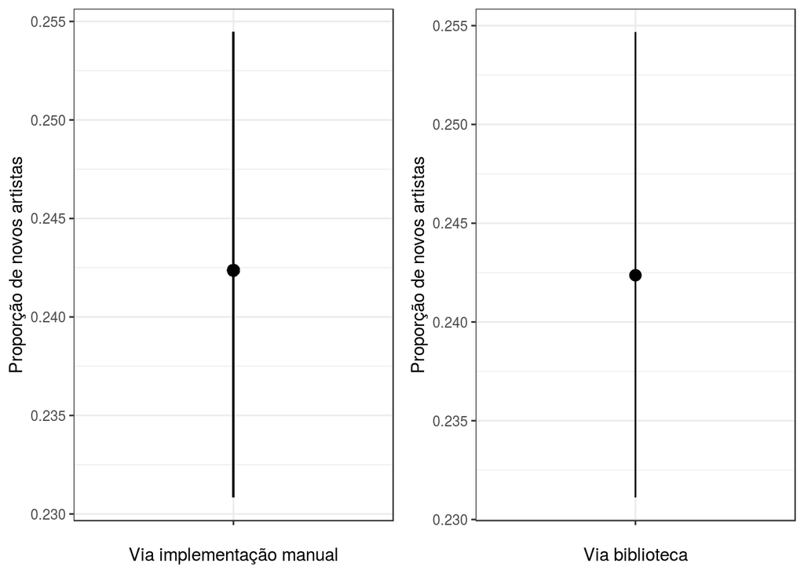

```r
plot1 = ci_manual %>%
    ggplot(aes(
        x = "",
        y = statistic,
        ymin = conf.low,
        ymax = conf.high
    )) +
    geom_pointrange() +
    geom_point(size = 3) +
    labs(x = "Via implementação manual",
         y = "Proporção de novos artistas")

plot2 = ci_via_boot %>%
    ggplot(aes(
        x = "",
        y = statistic,
        ymin = conf.low,
        ymax = conf.high
    )) +
    geom_pointrange() +
    geom_point(size = 3) +
    labs(x = "Via biblioteca",
         y = "Proporção de novos artistas")

grid.arrange(plot1, plot2, ncol = 2)
```

### 1. Conclusão

Na implementação manual foi obtido um valor de 0.242365 para o $\hat{\theta}$ e um intervalo de confiança de [0.2308375, 0.2544643]. Já na implementação via biblioteca (boot) foi obtido um valor de 0.242366 para o $\hat{\theta}$ e um intervalo de confiança de [0.2311165, 0.2546783].

Logo, os valores localizados dentro deste intervalo (para estimar o valor de $\theta$) não incluem o algarismo 0 e encontram-se cerca de uma casa decimal deste, o que aponta uma pequena diferença positiva. Com 95% de confiança, a partir dos dados da nossa amostra de tamanho 300, pode-se afirmar que a proporção de novos artistas escutados está entre 23% e 25% para todos os usuários da população, isto é, valor estimado para ${\theta}$.

## 2. Para os usuários que gostam de música muito pop (mediana_pop > 5), qual a correlação entre a popularidade mediana dos artistas escutado e a proporção dos artistas escutados que eram novos.

Primeiramente, analisa-se a distribuição dos dados de popularidade de mediana dos artista. Posteriormente, analisa-se a relação entre as duas variáveis mencionadas acima.

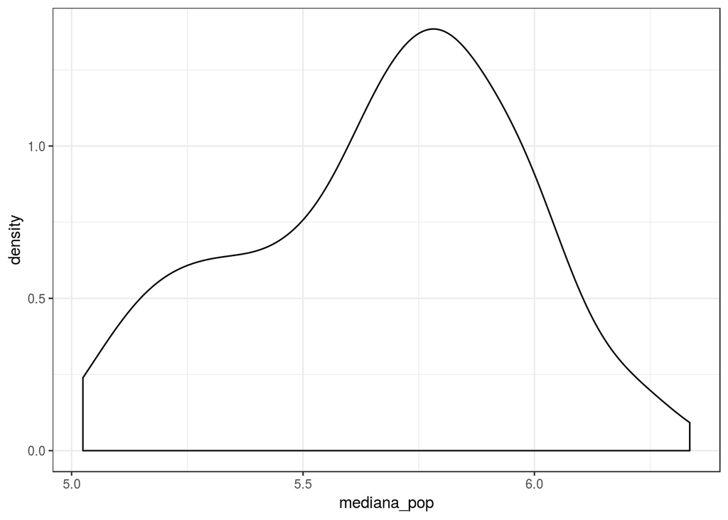

```r
minha_amostra_pop = minha_amostra %>%
    filter(mediana_pop > 5)  %>%
    ggplot(aes(mediana_pop)) +
    geom_density()
minha_amostra_pop
```

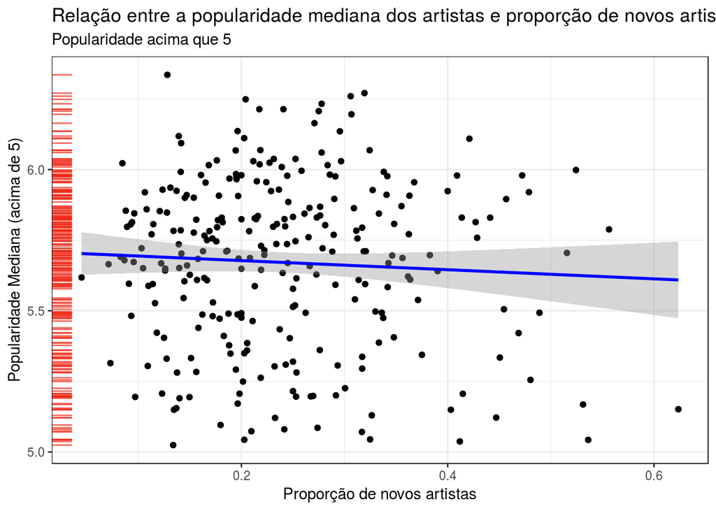

```r
minha_amostra_pop = minha_amostra %>%
    filter(mediana_pop > 5)  %>%
    ggplot(aes(x = proporcao_novos_artitas, y = mediana_pop)) +
    geom_point() +
    geom_rug(alpha = .7, color = "#EF2917", sides = "l") +
    geom_smooth(aes(x = proporcao_novos_artitas, y = mediana_pop), method="lm", color="blue") +
    labs(
    title = "Relação entre a popularidade mediana dos artistas e proporção de novos artistas",
    subtitle = "Popularidade acima que 5",
    x = "Proporção de novos artistas",
    y = "Popularidade Mediana (acima de 5)"
  )

minha_amostra_pop
```

```r
 minha_amostra_pop = minha_amostra %>%
    filter(mediana_pop > 5)  %>%
     summarise(pearson = cor(mediana_pop, proporcao_novos_artitas, method = "pearson"),
            spearman = cor(mediana_pop, proporcao_novos_artitas, method = "spearman"),
            kendall = cor(mediana_pop, proporcao_novos_artitas, method = "kendall"))
 minha_amostra_pop
```

| pearson | spearman | kendall |
| --- | --- | --- |
| -0.05679804 | 0.002998545 | 0.003223585 |

#### a. Implementando bootstraps manualmente

```r
minha_amostra_pop = minha_amostra %>%
    filter(mediana_pop > 5)

minha_amostra_pop
```

| news | old | mediana_pop | proporcao_novos_artitas |
| --- | --- | --- | --- |
| 25 | 103 | 5.966097 | 0.19531250 |
| 13 | 61 | 5.745970 | 0.17567568 |
| 21 | 62 | 5.195969 | 0.25301205 |
| 18 | 180 | 5.595928 | 0.09090909 |
| 10 | 55 | 5.900597 | 0.15384615 |
| 11 | 68 | 6.118659 | 0.13924051 |
| 29 | 120 | 5.291664 | 0.19463087 |
| 51 | 45 | 5.168289 | 0.53125000 |
| 23 | 61 | 5.085683 | 0.27380952 |
| 11 | 116 | 5.679136 | 0.08661417 |

[output cut: 260 more lines]

```r
funcao_theta_pop = function(df) {
    #sample_n(NROW(df),
    #replace = TRUE)

    boot_df <- sample_n(df,
                        NROW(df),
                        replace = TRUE)
    pearson = pull(boot_df %>%
        summarise(pearson = cor(x = mediana_pop, y = proporcao_novos_artitas, method = "pearson")))

    return(pearson)
}

set.seed(1212)

theta_c_pop_correlacao = funcao_theta_pop(minha_amostra_pop)
theta_c_pop_correlacao
```

```
## [1] -0.05612485
```

```r
repeticoes = 4000

# A REAMOSTRAGEM
reamostragens = tibble(i = 1:repeticoes) %>%
  mutate(theta_c_s = map_dbl(i, ~ funcao_theta_pop(minha_amostra_pop)))

reamostragens
```

| i | theta_c_s |
| --- | --- |
| 1 | -9.714547e-02 |
| 2 | -5.792955e-02 |
| 3 | -1.002150e-01 |
| 4 | -4.126688e-02 |
| 5 | -9.771191e-02 |
| 6 | -5.745506e-02 |
| 7 | -7.675793e-02 |
| 8 | -4.112824e-02 |
| 9 | 1.312994e-01 |
| 10 | -1.912310e-01 |

[output cut: 3990 more lines]

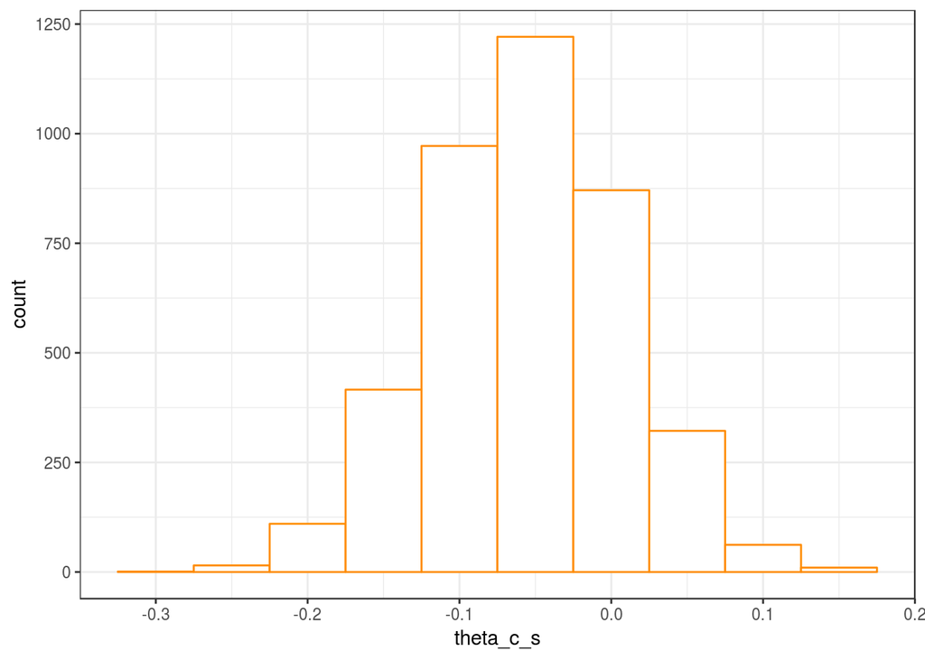

```r
ci_amostragens = reamostragens %>%
  mutate(erro = theta_c_s - theta_c_pop_correlacao) %>%
  mutate(conf.low = theta_c_pop_correlacao + quantile(erro, .025),
         conf.high = theta_c_pop_correlacao + quantile(erro, .975),
         statistic = theta_c_pop_correlacao) %>%
  select(conf.low, statistic, conf.high)

reamostragens %>%
  ggplot(aes(x = theta_c_s)) +
  geom_histogram(binwidth = .05,
                 colour = "darkorange",
                 fill = "white")
```

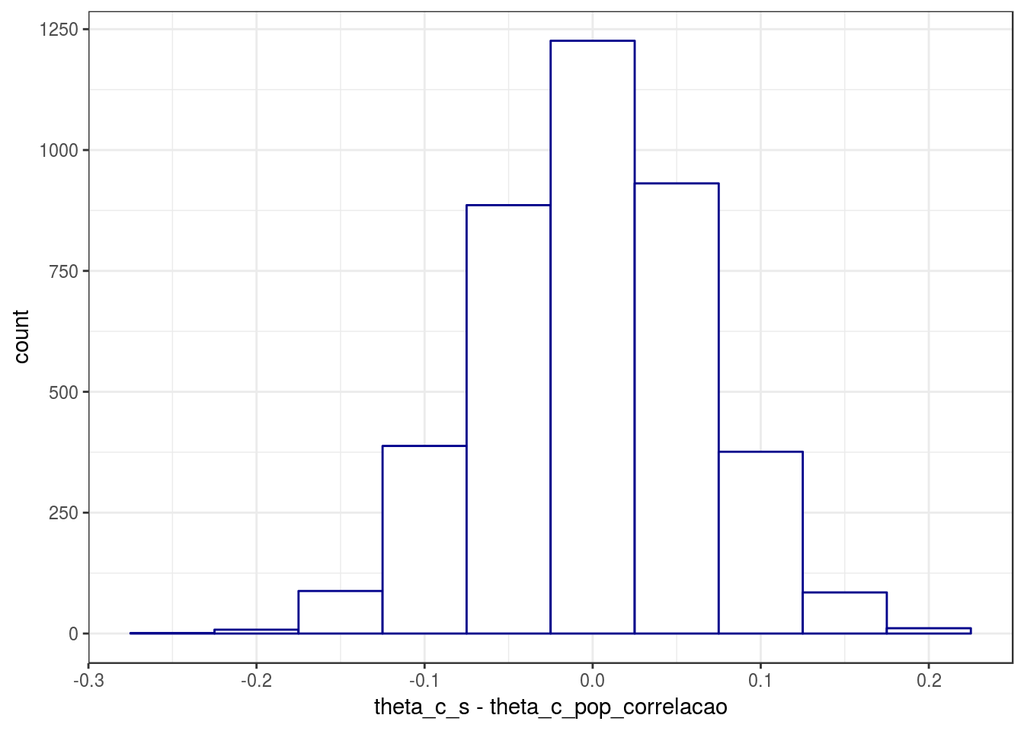

```r
reamostragens %>%
  ggplot(aes(x = theta_c_s - theta_c_pop_correlacao)) +
  geom_histogram(binwidth = .05,
                 colour = "darkblue",
                 fill = "white")
```

### Calculando o IC

Agora usamos a distribuição de $\delta* = \hat{\theta}* - \hat{\theta}$ no lugar da de $\delta$.

```r
intervalo = reamostragens %>%
  mutate(erro = theta_c_s - theta_c_pop_correlacao) %>%
  summarise(erro_i = quantile(erro, .025),
            erro_s = quantile(erro, .975))

#intervalo
```

Agora fazemos o mesmo que antes para estimar onde $\theta$ está usando $\hat{\theta}$.

```r
intervalo = intervalo %>%
  mutate(valor_i = theta_c_pop_correlacao + erro_i,
         valor_s = theta_c_pop_correlacao + erro_s)

intervalo
```

| erro_i | erro_s | valor_i | valor_s |
| --- | --- | --- | --- |
| -0.1237966 | 0.123968 | -0.1799214 | 0.06784313 |

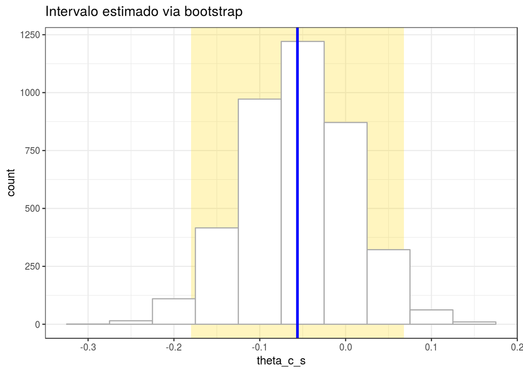

```r
ggplot() +
  geom_rect(
    data = intervalo,
    aes(xmin = valor_i, xmax = valor_s),
    ymin = -Inf,
    ymax = Inf,
    fill = "gold",
    alpha = .25
  ) +
  geom_histogram(
    data = reamostragens,
    aes(theta_c_s),
    binwidth = .05,
    fill = "white",
    colour = "darkgrey"
  ) +
  geom_vline(xintercept = theta_c_pop_correlacao,
             color = "blue",
             size = 1.2) +
  labs(title = expression("Intervalo estimado via bootstrap"))
```

Gera-se o detalhamento dos dados manualmente:

```r
ci_manual_pop = reamostragens %>%
  mutate(erro = theta_c_s - theta_c_pop_correlacao) %>%
  mutate(conf.low = theta_c_pop_correlacao + quantile(erro, .025),
         conf.high = theta_c_pop_correlacao + quantile(erro, .975),
         statistic = theta_c_pop_correlacao)

glimpse(ci_manual_pop)
```

```
## Observations: 4,000
## Variables: 6
## $ i         <int> 1, 2, 3, 4, 5, 6, 7, 8, 9, 10, 11, 12, 13, 14, 15, 16,…
## $ theta_c_s <dbl> -0.097145471, -0.057929546, -0.100214958, -0.041266876…
## $ erro      <dbl> -0.041020621, -0.001804697, -0.044090108, 0.014857974,…
## $ conf.low  <dbl> -0.1799214, -0.1799214, -0.1799214, -0.1799214, -0.179…
## $ conf.high <dbl> 0.06784313, 0.06784313, 0.06784313, 0.06784313, 0.0678…
## $ statistic <dbl> -0.05612485, -0.05612485, -0.05612485, -0.05612485, -0…
```

#### b. Calculando por meio da biblioteca do bootstrap (boot)

```r
library(boot)

theta <- function(d, i) {
    df = d %>%
            slice(i) %>%
            filter(mediana_pop > 5)
    cor(x = df$mediana_pop, y = df$proporcao_novos_artitas, method = "pearson")
}

booted <- boot(data = minha_amostra_pop,
               statistic = theta,
               R = 4000)

ci_via_boot_pop = tidy(booted,
          conf.level = .95,
          conf.method = "bca",
          conf.int = TRUE)

glimpse(ci_via_boot_pop)
```

```
## Observations: 1
## Variables: 5
## $ statistic <dbl> -0.05679804
## $ bias      <dbl> 5.941698e-05
## $ std.error <dbl> 0.06190067
## $ conf.low  <dbl> -0.1805113
## $ conf.high <dbl> 0.06210831
```

Agora, analisa-se os intervalos de confiança e o valor de theta.

[figure not shown]

```r
plot1 = ci_manual_pop %>%
    ggplot(aes(
        x = "",
        y = statistic,
        ymin = conf.low,
        ymax = conf.high
    )) +
    geom_pointrange() +
    geom_point(size = 3) +
    labs(x = "Via implementação manual",
         y = "Proporção de novos artistas")

plot2 = ci_via_boot_pop %>%
    ggplot(aes(
        x = "",
        y = statistic,
        ymin = conf.low,
        ymax = conf.high
    )) +
    geom_pointrange() +
    geom_point(size = 3) +
    labs(x = "Via biblioteca",
         y = "Proporção de novos artistas")

grid.arrange(plot1, plot2, ncol = 2)
```

### 2. Conclusão

Na implementação manual foi obtido um valor de -0.05612485 para o $\hat{\theta}$ e um intervalo de confiança de [-0.1799214, 0.06784313]. Já na implementação via biblioteca (boot) foi obtido um valor de -0.05679804 para o $\hat{\theta}$ e um intervalo de confiança de [-0.1805113, 0.06210831].